# Hand-in HW 8

Shuhan He

11/15/2020

```r
mm<-read.csv("MM-All (1).csv")
mm <- mutate(mm,NetWt=GrossWeight-1.3)
```

a)Create side-by-side boxplots of the net weights with proper labels and describe what you find (like back in Chapter 4), focusing on the comparison of the two samples.

The gross weight of a sample of packages of M&M’s bought in 2016 tended to have a wider range than those M&M’s bought in 2017.

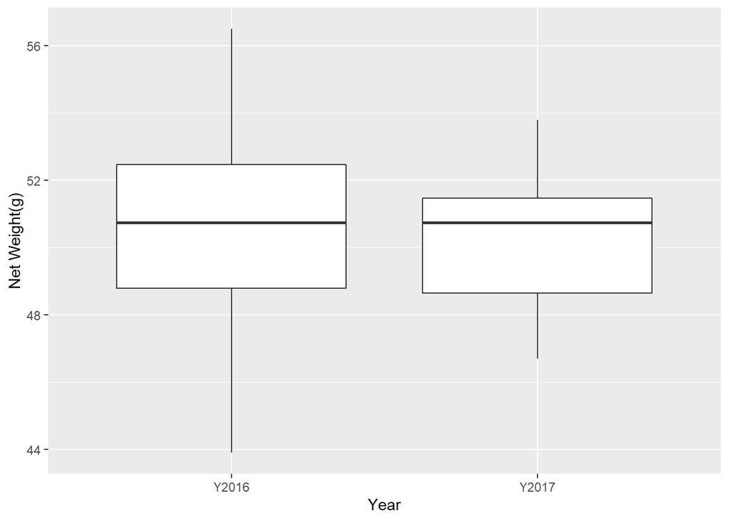

```r
ggplot(mm,aes(x=Year,y=NetWt)) + geom_boxplot() +
  ylab("Net Weight(g)")
```

b)Do the assumptions of t procedures appear satisfied?

Since these are random samples from shipments of M&M’s the store received in the respective years, the randomization condition is met. The sample size of M&M’s does not exceed 10% of the population which is the total amount of packages that M&M produced in 2016 and 2017. The data we gathered contains come from a normal population. On conclusion, the t procedures appear satisfied.

c)Report the group means, standard deviations and sample sizes in a table (see the summaryBy command in 10 d) on p. 6 of “Some relevant R commands” in Moodle).

```r
summaryBy(NetWt~Year,data=mm,FUN=c(mean,sd,length))
```

```
##    Year NetWt.mean NetWt.sd NetWt.length
## 1 Y2016   50.59667 3.116307           30
## 2 Y2017   50.30556 2.114786           18
```

d)Report the 99% confidence interval for the difference in means and interpret in the context of the problem. Use the t.test command. You can extract the endpoints of the confidence interval by saving the result of the t.test command, say in tt. Then the endpoints of the confidence interval are tt$conf.int[1] and tt$conf.int[2].

```r
qnorm(0.995)
```

```
## [1] 2.575829
```

```r
ybar<-mean(mm$NetWt)
se<-sd(mm$NetWt)/sqrt(48)
me<-qt(0.995,47)*se
c(ybar-me,ybar+me)
```

```
## [1] 49.41718 51.55782
```

```r
tt<-t.test(mm$NetWt,mu=49.3)
tt
```

```
##
##  One Sample t-test
##
## data:  mm$NetWt
## t = 2.9785, df = 47, p-value = 0.004572
## alternative hypothesis: true mean is not equal to 49.3
## 95 percent confidence interval:
##  49.68542 51.28958
## sample estimates:
## mean of x
##   50.4875
```

e)Report the P-value (from t.test) for a two-sided test of the hypothesis that the two population means are equal and interpret in the contest of the problem. Do not use reject/don’t reject or significant/not significant terminology. Talk about strength of evidence. You can extract the P-value from the saved t.test command with tt$p.value.

```r
t <- (ybar-49.3)/se
2*pt(-t,47)
```

```
## [1] 0.00457151
```